# R Notebook

For this assignment we will emphasize the bootstrapping concept, of taking a sample and repeatedly sampling with and without replacement. We are going to analyze the mean of applications received to 777 colleges and universities. This data was received by the 1995 US and World report.

I will first download the necessary dependencies in order to begin this assessment.

```r
library(ISLR)
dim(College)
```

```
[1] 777  18
```

```r
head(College)
```

|  | Private | Apps | Accept | Enroll | Top10perc | Top25perc | F.Undergrad | P.Undergrad | Outstate | Room.Board | Books | Personal | PhD | Terminal | S.F.Ratio | perc.alumni | Expend | Grad.Rate |
| --- | --- | --- | --- | --- | --- | --- | --- | --- | --- | --- | --- | --- | --- | --- | --- | --- | --- | --- |
| Abilene Christian University | Yes | 1660 | 1232 | 721 | 23 | 52 | 2885 | 537 | 7440 | 3300 | 450 | 2200 | 70 | 78 | 18.1 | 12 | 7041 | 60 |
| Adelphi University | Yes | 2186 | 1924 | 512 | 16 | 29 | 2683 | 1227 | 12280 | 6450 | 750 | 1500 | 29 | 30 | 12.2 | 16 | 10527 | 56 |
| Adrian College | Yes | 1428 | 1097 | 336 | 22 | 50 | 1036 | 99 | 11250 | 3750 | 400 | 1165 | 53 | 66 | 12.9 | 30 | 8735 | 54 |
| Agnes Scott College | Yes | 417 | 349 | 137 | 60 | 89 | 510 | 63 | 12960 | 5450 | 450 | 875 | 92 | 97 | 7.7 | 37 | 19016 | 59 |
| Alaska Pacific University | Yes | 193 | 146 | 55 | 16 | 44 | 249 | 869 | 7560 | 4120 | 800 | 1500 | 76 | 72 | 11.9 | 2 | 10922 | 15 |
| Albertson College | Yes | 587 | 479 | 158 | 38 | 62 | 678 | 41 | 13500 | 3335 | 500 | 675 | 67 | 73 | 9.4 | 11 | 9727 | 55 |

Now after our initial data exploration, we can now dive in a bit. In order to demonstrate the capabilities of bootstrapping, I will calculate the mean of all the apps recieved per college and store it in a variable “original_mean”. Then in order to do the bootstrap, I will create an empty list called “boots”. Then we will sample the mean 1000 different times and each time, the new mean will be added to the list until we have 1000 means on that list. When we do the resampling, we will resample WITH replacement to emphasize real world phenomenas in data sampling.

```r
original_mean <- mean(College$Apps)
original_mean
```

```
[1] 3001.638
```

```r
set.seed(1)
Mine <- Sys.time()
boots <- NULL

for(i in 1:1000){
  sample <- mean(sample(College$Apps, 777, replace=TRUE))
  boots <- c(boots, sample)
}

Mine2 <- Sys.time()

Mine2 - Mine
```

```
Time difference of 0.103503 secs
```

```r
ci_80 <- quantile(boots, c(.10, .90))



ci_80_2 <- original_mean + 2*c(-sd(boots), sd(boots))

cat("quantile version", ci_80, "\n")
```

```
quantile version 2822.129 3178.496
```

```r
cat("standard deviation version", ci_80_2)
```

```
standard deviation version 2725.847 3277.43
```

Now for the second part, we are going to use different seeds to see if there is a huge deviation in the calculations.

```r
set.seed(2)

boots2 <- NULL

for(i in 1:1000){
  sample <- mean(sample(College$Apps, 777, replace=TRUE))
  boots2 <- c(boots2, sample)
}

ci_80 <- quantile(boots2, c(.10, .90))

ci_80_2 <- original_mean + 2*c(-sd(boots2), sd(boots))

cat("quantile version", ci_80, "\n")
```

```
quantile version 2841.211 3183.113
```

```r
cat("standard deviation version", ci_80_2)
```

```
standard deviation version 2730.62 3277.43
```

```r
set.seed(3)

boots3 <- NULL

for(i in 1:1000){
  sample <- mean(sample(College$Apps, 777, replace = TRUE))
  boots3 <- c(boots3, sample)
}

ci_80 <- quantile(boots3, c(.10, .90))

ci_80_2 <- original_mean + 2*c(-sd(boots), sd(boots))

cat("quantile version", ci_80, "\n")
```

```
quantile version 2829.913 3184.565
```

```r
cat("standard deviation version", ci_80_2)
```

```
standard deviation version 2725.847 3277.43
```

As we see, even with the different seeds, our estimates do not deviate much which makes us feel good as we can tell our stakeholders that the general mean is anywhere between 2700 to 3200 apps. Changing the seed does not seem to drastically change our calculations. Also, most importantly, they don’t seem to deviate from the initial “original mean” stored in orignal_mean.

There is one last thing we can look at. We can now check if, maybe, changing the amount of bootstrap samples from 1000 to 5000 will change anything. We will even go as far as reusing seed numbers.

```r
set.seed(1)

boots2 <- NULL

for(i in 1:5000){
  sample <- mean(sample(College$Apps, 777, replace=TRUE))
  boots <- c(boots, sample)
}

ci_80 <- quantile(boots, c(.10, .90))

ci_80_2 <- original_mean + 2*c(-sd(boots), sd(boots))

cat("quantile version", ci_80, "\n")
```

```
quantile version 2825.475 3182.251
```

```r
cat("standard deviation version", ci_80_2)
```

```
standard deviation version 2722.839 3280.438
```

```r
set.seed(2)

boots2 <- NULL

for(i in 1:5000){
  sample <- mean(sample(College$Apps, 777, replace=TRUE))
  boots2 <- c(boots2, sample)
}

ci_80 <- quantile(boots2, c(.10, .90))

ci_80_2 <- original_mean + 2*c(-sd(boots2), sd(boots2))

cat("quantile version", ci_80, "\n")
```

```
quantile version 2828.61 3184.023
```

```r
cat("standard deviation version", ci_80_2)
```

```
standard deviation version 2722.846 3280.43
```

```r
set.seed(3)

boots3 <- NULL

for(i in 1:5000){
  sample <- mean(sample(College$Apps, 777, replace=TRUE))
  boots3 <- c(boots3, sample)
}

ci_80 <- quantile(boots3, c(.10, .90))

ci_80_2 <- original_mean + 2*c(-sd(boots3), sd(boots3))

cat("quantile version", ci_80, "\n")
```

```
quantile version 2825.658 3182.218
```

```r
cat("standard deviation version", ci_80_2)
```

```
standard deviation version 2723.752 3279.525
```

Again, nothing seems to deviate much regardless of the bootstrapping sample or the seed that was set. This shows that our calculation is very robust, in other words, it is very consistent.

```r
CollegeApps_Mean <- tapply(College$Apps, College$Private, mean)
CollegeApps_Mean
```

```
      No      Yes
5729.920 1977.929
```

```r
CollegeDifferenceOriginal <- CollegeApps_Mean[2] - CollegeApps_Mean[1]
CollegeDifferenceOriginal
```

```
      Yes
-3751.991
```

```r
NewPrivate <- sample(College$Private, length(College$Private), replace=FALSE)

NewCollege <- data.frame(Apps=College$Apps, Private=NewPrivate)

set.seed(400)

SampleNoise <- NULL

mine3 <- Sys.time()

for(i in 1:10000){
  NewPrivate <- sample(College$Private, length(College$Private), replace=FALSE)
  NewCollege <- data.frame(Apps=College$Apps, Private = NewPrivate)
  CollegeApps_Mean <- tapply(NewCollege$Apps, NewCollege$Private, mean)
  CollegeDifference <- CollegeApps_Mean[2] - CollegeApps_Mean[1]
  SampleNoise <- c(SampleNoise, CollegeDifference)
}

mine4 <- Sys.time()

mine4 - mine3
```

```
Time difference of 3.369002 secs
```

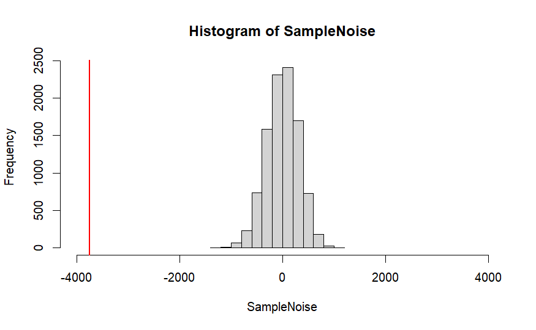

```r
hist(SampleNoise, xlim=c(-4000, 4000))
abline(v = CollegeDifferenceOriginal, col="red", lwd = 2)
```

Looking at our chart, the p-value is not even in the distribution, it is way to the left indicating a negative value. Since we are subtracting the mean apps of public schools from the mean app of private school from the original data, this resulted in a large negative value. Even if we had done the other way, subtracting the mean value of private from the mean value of public, it would still be outside our distribution. Visually, this tells us to reject the null hypothesis. Before that, we will do one last calculation to see it in pure numbers.

```r
Lessthanoriginal <- SampleNoise < CollegeDifferenceOriginal
sum(Lessthanoriginal)/10000
```

```
[1] 0
```